# Project Foundations for Data Science: FoodHub Data Analysis

### **Question 7**: Which are the top 5 restaurants in terms of the number of orders received? [1 mark]

```python
# Write the code here
df['restaurant_name'].value_counts()[:5]  #top 5 restaurants in number of orders
```

| restaurant_name | count |
| --- | --- |
| Shake Shack | 219 |
| The Meatball Shop | 132 |
| Blue Ribbon Sushi | 119 |
| Blue Ribbon Fried Chicken | 96 |
| Parm | 68 |

**dtype:** int64

#### Observations:

Shake Shack topping the orders received at 219 orders followed by The Meetball shop at 132 orders

### **Question 8**: Which is the most popular cuisine on weekends? [1 mark]

```python
# Write the code here
df[df['day_of_the_week'] == 'Weekend']['cuisine_type'].value_counts() #count of orders during weekends
```

| cuisine_type | count |
| --- | --- |
| American | 415 |
| Japanese | 335 |
| Italian | 207 |
| Chinese | 163 |
| Mexican | 53 |
| Indian | 49 |
| Mediterranean | 32 |
| Middle Eastern | 32 |
| Thai | 15 |
| French | 13 |
| Korean | 11 |
| Southern | 11 |
| Spanish | 11 |
| Vietnamese | 4 |

**dtype:** int64

#### Observations:

American, Japanese, Italan and Chinese are the top 4 cuisines on weekends

### **Question 9**: What percentage of the orders cost more than 20 dollars? [2 marks]

```python
# Write the code here
orders_greater_than_20=df[df['cost_of_the_order'] > 20].shape[0] #Orders greater then 20 dollars
total_orders=df.shape[0] #total orders
print("The percentage of orders cost more than 20 dollars is",round((orders_greater_than_20/total_orders)*100,2),"%")
```

```
The percentage of orders cost more than 20 dollars is 29.24 %
```

#### Observations:

29.24% of orders cost more than 20 dollars

### **Question 10**: What is the mean order delivery time? [1 mark]

```python
# Write the code here
df['delivery_time'].mean() #mean order delivery time
```

```
24.161749209694417
```

#### Observations:

The mean order delivery time is 24.16 minutes

### **Question 11:** The company has decided to give 20% discount vouchers to the top 3 most frequent customers. Find the IDs of these customers and the number of orders they placed. [1 mark]

```python
# Write the code here
df['customer_id'].value_counts().nlargest(3) #top 3 customer ids with most number of orders
```

| customer_id | count |
| --- | --- |
| 52832 | 13 |
| 47440 | 10 |
| 83287 | 9 |

**dtype:** int64

### **Question 12**: Perform a multivariate analysis to explore relationships between the important variables in the dataset. (It is a good idea to explore relations between numerical variables as well as relations between numerical and categorical variables) [10 marks]

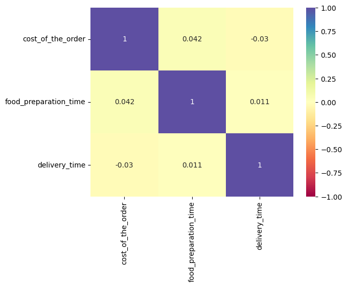

```python
# Write the code here
#plt.figure(figsize=(10,5))
#heat map to compare the corrulation between integer columns in the data set
sns.heatmap(df[['cost_of_the_order','food_preparation_time','delivery_time']].corr(), annot=True, cmap="Spectral", vmin=-1, vmax=1)
plt.show()
```

Observation

There is not much corrulation on delivery time with cost of order and food preparation time. It tend to be around mean

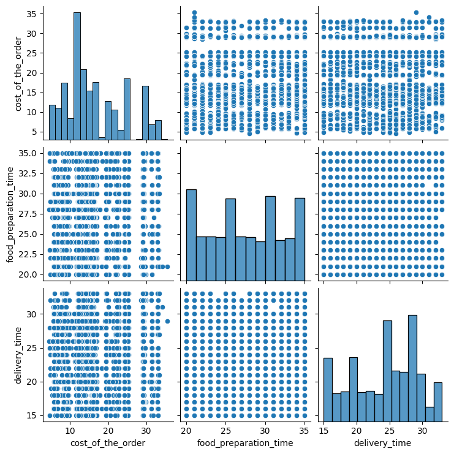

```python
sns.pairplot(df[['cost_of_the_order','food_preparation_time','delivery_time']]) #plot to show the corrulation
plt.show()
```

As we can see the data set has data all through the possiblities where delivery time increased with low cost of order as well as high cost of order. This is the same case with food preparation time

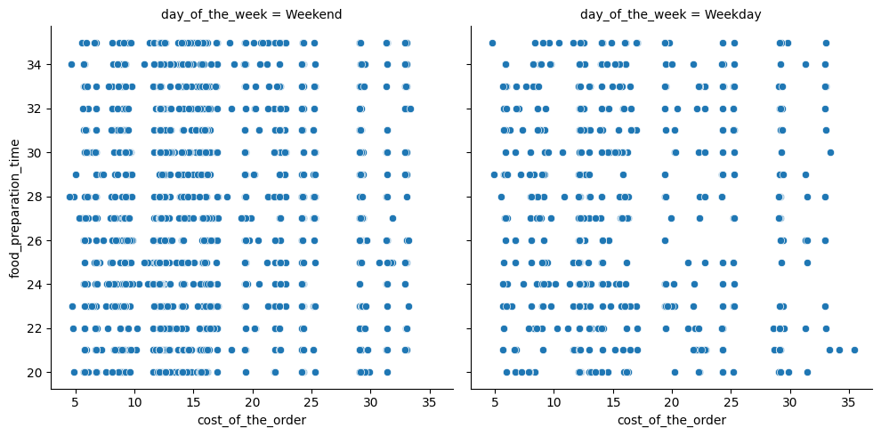

```python
sns.relplot(data=df, x='cost_of_the_order', y='food_preparation_time', col='day_of_the_week') #relation plot helps to identify relation between numerial and non numerical data
plt.show()
```

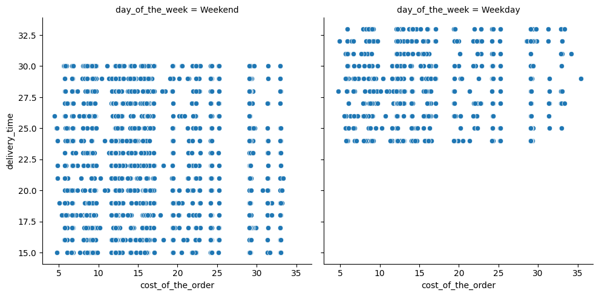

```python
sns.relplot(data=df, x='cost_of_the_order', y='delivery_time', col='day_of_the_week') #relation plot of delivery time and days of week
plt.show()
```

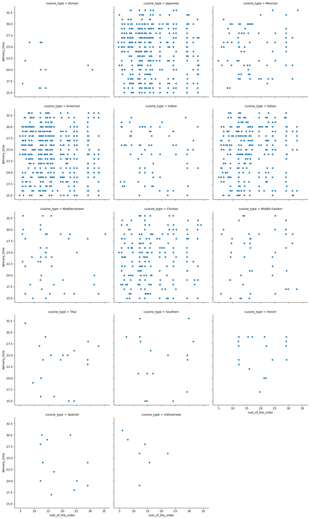

```python
sns.relplot(data=df, x='cost_of_the_order', y='delivery_time', col='cuisine_type', col_wrap=3) #relation plot with cuisine and delivery time
plt.show()
```

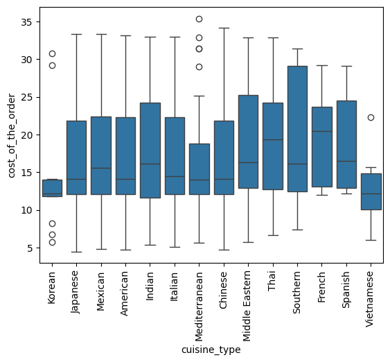

```python
sns.boxplot(data=df, x='cuisine_type', y='cost_of_the_order')
plt.xticks(rotation=90)
plt.show()
```

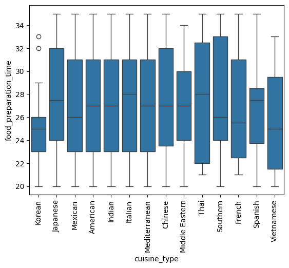

```python
sns.boxplot(data=df, x='cuisine_type', y='food_preparation_time')
plt.xticks(rotation=90)
plt.show()
```

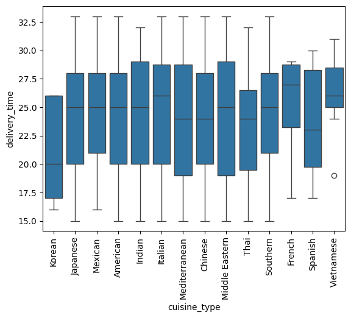

```python
sns.boxplot(data=df, x='cuisine_type', y='delivery_time')
plt.xticks(rotation=90)
plt.show()
```

### **Question 13:** The company wants to provide a promotional offer in the advertisement of the restaurants. The condition to get the offer is that the restaurants must have a rating count of more than 50 and the average rating should be greater than 4. Find the restaurants fulfilling the criteria to get the promotional offer. [3 marks]

```python
# Write the code here
df['rating_int'] = df['rating'].apply(lambda x: 0 if x == 'Not given' else x)
```

```python
df_rating_available=df[df['rating'] != 'Not given']
df_rating_available['rating_int'] = df_rating_available['rating'].apply(lambda x: int(x))
```

```python
df_rating_available.groupby(['restaurant_name'])['rating'].agg(['count','mean']).loc[(df_rating_available.groupby(['restaurant_name'])['rating'].agg(['count'])['count'] > 50) & (df_rating_available.groupby(['restaurant_name'])['rating'].agg(['mean'])['mean'] > 4)]
```

| restaurant_name | count | mean |
| --- | --- | --- |
| Blue Ribbon Fried Chicken | 64 | 4.328125 |
| Blue Ribbon Sushi | 73 | 4.219178 |
| Shake Shack | 133 | 4.278195 |
| The Meatball Shop | 84 | 4.511905 |

#### Observations:

The eligible restaurants are Blue Ribbon Fried Chicken,Blue Ribbon Sushi,Shake Shack and The Meatball Shop

### **Question 14:** The company charges the restaurant 25% on the orders having cost greater than 20 dollars and 15% on the orders having cost greater than 5 dollars. Find the net revenue generated by the company across all orders. [3 marks]

```python
# Write the code here
df['net_revenue'] = np.where(df['cost_of_the_order'] > 20, (df['cost_of_the_order']*25)/100, np.where(df['cost_of_the_order'] > 5, (df['cost_of_the_order']*15)/100, df['cost_of_the_order']))
df_net_revenue = df.groupby('restaurant_name')['net_revenue'].sum().sum()
df_net_revenue
```

```
6209.043
```

### **Question 15:** The company wants to analyze the total time required to deliver the food. What percentage of orders take more than 60 minutes to get delivered from the time the order is placed? (The food has to be prepared and then delivered.) [2 marks]

```python
# Write the code here
df['total_time']=df['food_preparation_time']+df['delivery_time']
perc=df[df['total_time'] > 60].shape[0]/df.shape[0]*100
print("The percentage of orders take more than 60 minutes to get delivered is",round(perc,2),"%")
```

```
The percentage of orders take more than 60 minutes to get delivered is 10.54 %
```

#### Observations:

Around 10.54 % of orders take more than 60 minutes to get delivered

### **Question 16:** The company wants to analyze the delivery time of the orders on weekdays and weekends. How does the mean delivery time vary during weekdays and weekends? [2 marks]

```python
# Write the code here
df.groupby(['day_of_the_week'])['delivery_time'].mean()
```

| day_of_the_week | delivery_time |
| --- | --- |
| Weekday | 28.340037 |
| Weekend | 22.470022 |

**dtype:** float64

#### Observations:

Then mean delivery time on weekday is 28.34 minutes and on weekend is 22.47 minutes

### Conclusion and Recommendations

### **Question 17:** What are your conclusions from the analysis? What recommendations would you like to share to help improve the business? (You can use cuisine type and feedback ratings to drive your business recommendations.) [6 marks]

```python
df_rating_available.groupby(['cuisine_type'])['rating_int'].agg(['count','mean']).nlargest(5,'count')
```

| cuisine_type | count | mean |
| --- | --- | --- |
| American | 368 | 4.298913 |
| Japanese | 273 | 4.373626 |
| Italian | 172 | 4.360465 |
| Chinese | 133 | 4.338346 |
| Indian | 50 | 4.540000 |

```python
df_rating_available.groupby(['cuisine_type'])['rating_int'].agg(['count','mean']).nlargest(5,'mean')
```

| cuisine_type | count | mean |
| --- | --- | --- |
| Spanish | 6 | 4.833333 |
| Thai | 9 | 4.666667 |
| Indian | 50 | 4.540000 |
| Mexican | 48 | 4.416667 |
| Japanese | 273 | 4.373626 |

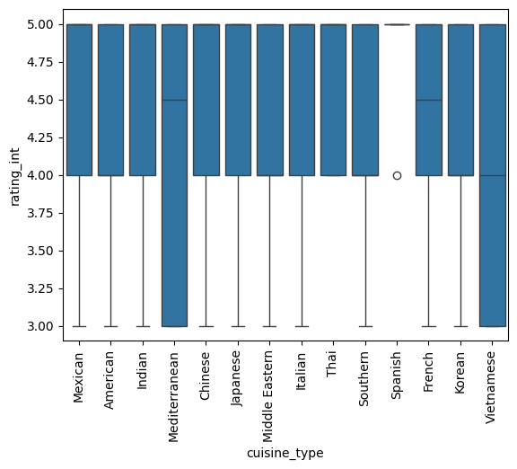

```python
sns.boxplot(data=df_rating_available, x='cuisine_type', y='rating_int')
plt.xticks(rotation=90)
plt.show()
```

### Conclusions:

- American, Japanese, Italian, Chinese are the top 4 cuisines ordered
- Spanish rating lies as an outlier
- Thai rating is more than 4
- Indian, Mexican are also with high ratings

### Recommendations:

- Recommend more Thai, Indian and Mexican food to customers as it has high raitings
- Encourage customers who ordered Spanish to provide rating
- Recommend more American, Japanese, Italian & Chinese to get new customers as it has highest number of orders